# INTRODUCTION TO THE PROJECT

This project is about wrangling, assessing and cleaning for analysis purpose.

The goal: wrangle WeRateDogs Twitter data to create interesting and trustworthy analyses and visualizations. The Twitter archive is great, but it only contains very basic tweet information. Additional gathering, then assessing and cleaning is required for "Wow!"-worthy analyses and visualizations.

## What are the data and where they come from?

The data which will be used are about people's dogs rating. The dataset that will be wrangled (and analyzed and visualized) is the tweet archive of Twitter user @dog_rates, also known as WeRateDogs. WeRateDogs is a Twitter account that rates people's dogs with a humorous comment about the dog. These ratings almost always have a denominator of 10. The numerators, though? Almost always greater than 10. 11/10, 12/10, 13/10, etc. Why? Because "they're good dogs Brent." WeRateDogs has over 4 million followers and has received international media coverage.

## Where those data come from?

For this project we have three sources for the data:

1) Enhanced Twitter Archive, which comes on a csv file fomat:

The WeRateDogs Twitter archive contains basic tweet data for all 5000+ of their tweets, but not everything. One column the archive does contain though: each tweet's text, which are used to extract rating, dog name, and dog "stage" (i.e. doggo, floofer, pupper, and puppo) to make this Twitter archive "enhanced." Of the 5000+ tweets, the author has filtered for tweets with ratings only (there are 2356).

2) Additional Data via the Twitter API

Back to the basic-ness of Twitter archives: retweet count and favorite count are two of the notable column omissions. Fortunately, this additional data can be gathered by anyone from Twitter's API. Well, "anyone" who has access to data for the 3000 most recent tweets, at least. The WeRateDogs Twitter archive and specifically the tweet IDs within it, will allow gathering this data for all 5000+. We're going to query Twitter's API to gather this valuable data.

3) Image Predictions File

The author ran every image in the WeRateDogs Twitter archive through a neural network that can classify breeds of dogs*. The results: a table full of image predictions (the top three only) alongside each tweet ID, image URL, and the image number that corresponded to the most confident prediction (numbered 1 to 4 since tweets can have up to four images).

# GATHERING THE DATA

data are available from three differents sources, which will require programmatic gathering according to the format and the source of the data.

Three pieces of data will be gathered :

1. The WeRateDogs Twitter archive, which is a .csv format : twitter_archive_enhanced.csv
2. The tweet image predictions, i.e., what breed of dog (or other object, animal, etc.) is present in each tweet according to a neural network. This file (image_predictions.tsv) is hosted on a server.
3. Each tweet's retweet count and favorite ("like") count at minimum, and any interesting additional data you find interesting.

```python
# let's import all the librairies needed for this project
import pandas as pd
import tweepy
import numpy as np
import requests
import json
import os
```

```python
# let's create a pandas dataframe from the first piece of data : " twitter_archive_enhanced.csv "
twiter_archive_enhance=pd.read_csv('twitter-archive-enhanced.csv')
```

```python
twiter_archive_enhance.head()
```

|  | tweet_id | in_reply_to_status_id | in_reply_to_user_id | timestamp | source | text | retweeted_status_id | retweeted_status_user_id | retweeted_status_timestamp | expanded_urls | rating_numerator | rating_denominator | name | doggo | floofer | pupper | puppo |
| --- | --- | --- | --- | --- | --- | --- | --- | --- | --- | --- | --- | --- | --- | --- | --- | --- | --- |
| 0 | 892420643555336193 | NaN | NaN | 2017-08-01 16:23:56 +0000 | <a href="http://twitter.com/download/iphone" r... | This is Phineas. He's a mystical boy. Only eve... | NaN | NaN | NaN | https://twitter.com/dog_rates/status/892420643... | 13 | 10 | Phineas | None | None | None | None |
| 1 | 892177421306343426 | NaN | NaN | 2017-08-01 00:17:27 +0000 | <a href="http://twitter.com/download/iphone" r... | This is Tilly. She's just checking pup on you.... | NaN | NaN | NaN | https://twitter.com/dog_rates/status/892177421... | 13 | 10 | Tilly | None | None | None | None |
| 2 | 891815181378084864 | NaN | NaN | 2017-07-31 00:18:03 +0000 | <a href="http://twitter.com/download/iphone" r... | This is Archie. He is a rare Norwegian Pouncin... | NaN | NaN | NaN | https://twitter.com/dog_rates/status/891815181... | 12 | 10 | Archie | None | None | None | None |
| 3 | 891689557279858688 | NaN | NaN | 2017-07-30 15:58:51 +0000 | <a href="http://twitter.com/download/iphone" r... | This is Darla. She commenced a snooze mid meal... | NaN | NaN | NaN | https://twitter.com/dog_rates/status/891689557... | 13 | 10 | Darla | None | None | None | None |
| 4 | 891327558926688256 | NaN | NaN | 2017-07-29 16:00:24 +0000 | <a href="http://twitter.com/download/iphone" r... | This is Franklin. He would like you to stop ca... | NaN | NaN | NaN | https://twitter.com/dog_rates/status/891327558... | 12 | 10 | Franklin | None | None | None | None |

```python
twiter_archive_enhance.shape
```

```
(2356, 17)
```

the first piece of data has 2356 tweets of the 5000+ tweets. Those are tweets with ratings only.

```python
# let's gather data from the second piece of data : "image_predictions.tsv"
url='https://d17h27t6h515a5.cloudfront.net/topher/2017/August/599fd2ad_image-predictions/image-predictions.tsv'
response=requests.get(url)
```

```python
# let's save tsv to file
with open('image-predictions.tsv', mode='wb') as file:
    file.write(response.content)
```

```python
# Let's create a dataframe with 'image-predictions.tsv'
image_predictions=pd.read_csv('image-predictions.tsv', sep='\t')
```

```python
image_predictions
```

|  | tweet_id | jpg_url | img_num | p1 | p1_conf | p1_dog | p2 | p2_conf | p2_dog | p3 | p3_conf | p3_dog |
| --- | --- | --- | --- | --- | --- | --- | --- | --- | --- | --- | --- | --- |
| 0 | 666020888022790149 | https://pbs.twimg.com/media/CT4udn0WwAA0aMy.jpg | 1 | Welsh_springer_spaniel | 0.465074 | True | collie | 0.156665 | True | Shetland_sheepdog | 0.061428 | True |
| 1 | 666029285002620928 | https://pbs.twimg.com/media/CT42GRgUYAA5iDo.jpg | 1 | redbone | 0.506826 | True | miniature_pinscher | 0.074192 | True | Rhodesian_ridgeback | 0.072010 | True |
| 2 | 666033412701032449 | https://pbs.twimg.com/media/CT4521TWwAEvMyu.jpg | 1 | German_shepherd | 0.596461 | True | malinois | 0.138584 | True | bloodhound | 0.116197 | True |
| 3 | 666044226329800704 | https://pbs.twimg.com/media/CT5Dr8HUEAA-lEu.jpg | 1 | Rhodesian_ridgeback | 0.408143 | True | redbone | 0.360687 | True | miniature_pinscher | 0.222752 | True |
| 4 | 666049248165822465 | https://pbs.twimg.com/media/CT5IQmsXIAAKY4A.jpg | 1 | miniature_pinscher | 0.560311 | True | Rottweiler | 0.243682 | True | Doberman | 0.154629 | True |
| ... | ... | ... | ... | ... | ... | ... | ... | ... | ... | ... | ... | ... |
| 2070 | 891327558926688256 | https://pbs.twimg.com/media/DF6hr6BUMAAzZgT.jpg | 2 | basset | 0.555712 | True | English_springer | 0.225770 | True | German_short-haired_pointer | 0.175219 | True |
| 2071 | 891689557279858688 | https://pbs.twimg.com/media/DF_q7IAWsAEuuN8.jpg | 1 | paper_towel | 0.170278 | False | Labrador_retriever | 0.168086 | True | spatula | 0.040836 | False |
| 2072 | 891815181378084864 | https://pbs.twimg.com/media/DGBdLU1WsAANxJ9.jpg | 1 | Chihuahua | 0.716012 | True | malamute | 0.078253 | True | kelpie | 0.031379 | True |
| 2073 | 892177421306343426 | https://pbs.twimg.com/media/DGGmoV4XsAAUL6n.jpg | 1 | Chihuahua | 0.323581 | True | Pekinese | 0.090647 | True | papillon | 0.068957 | True |
| 2074 | 892420643555336193 | https://pbs.twimg.com/media/DGKD1-bXoAAIAUK.jpg | 1 | orange | 0.097049 | False | bagel | 0.085851 | False | banana | 0.076110 | False |

2075 rows × 12 columns

third piece of data the tweets text. I want to get access to the WeRateDogs Twitter. Query the Twitter API for each tweet's JSON data using Python's Tweepy library and store each tweet's entire set of JSON data in a file called tweet_json.txt file. Each tweet's JSON data should be written to its own line. Then read this .txt file line by line into a pandas DataFrame with (at minimum) tweet ID, retweet count, and favorite count. I create a twitter app, to get authentification.

```python
# I create a dictionary to store my twitter credentials
import json
twitter_cred=dict()

twitter_cred['CONSUMER_KEY'] = ''
twitter_cred['CONSUMER_SECRET'] = ''
twitter_cred['ACCESS_KEY'] = ''
twitter_cred['ACCESS_SECRET'] =''

# Let's save the information to a json so that it can be reused in code without exposing
# the secret info to public

with open('twitter_credentials.json','w') as secret_info:
    json.dump(twitter_cred,secret_info, indent=4, sort_keys=True)
```

```python
import tweepy, json
from tweepy import OAuthHandler
from timeit import default_timer as timer
import datetime
from datetime import datetime
import csv
import re

# load Twitter API credentials

with open('twitter_credentials.json') as cred_data:
    info=json.load(cred_data)
access_token=info['ACCESS_KEY']
access_token_secret=info['ACCESS_SECRET']
consumer_key=info['CONSUMER_KEY']
consumer_secret=info['CONSUMER_SECRET']

try:
    api.verify_credentials()
    print("Authentication Ok")
except:
    print("Error during authentication")
```

[output not shown]

```python
tweet_ids=twiter_archive_enhance.tweet_id.values
len(tweet_ids)
```

```
2356
```

```python
auth = tweepy.OAuthHandler(consumer_key, consumer_secret)
auth.set_access_token(access_token, access_token_secret)

api = tweepy.API(auth,wait_on_rate_limit=True)

# Query Twitter's API for JSON data for each tweet ID in the Twitter archive

count=0
fails_dict={}
start=timer()

# Save each tweet's returned JSON as a new line in a .txt file

with open('tweet_json.txt', 'w') as outfile:
    for tweet_id in tweet_ids :
        count += 1
        print(str(count) + ": " + str(tweet_id))

        try:
            tweet = api.get_status(tweet_id, tweet_mode='extended')
            print("Success")
            json.dump(tweet._json, outfile)
            outfile.write('\n')
        except tweepy.TweepError as e:
            print("Fail")
            fails_dict[tweet_id]=e
            pass
end=timer()
print(end - start)
print(fails_dict)
```

[output not shown]

[output cut: 4659 more lines]

[output not shown]

```python
# Import package
import json

# String of path to file: tweets_data_path
tweets_data_path='tweet_json.txt'

# Initialize empty list to store tweets: tweets_data
tweets_data=[]

# Open connection to file
tweets_file = open(tweets_data_path, "r")

# Read in tweets and store in list: tweets_data
for line in tweets_file:
    tweet=json.loads(line)
    tweets_data.append(tweet)

# Close connection to file
tweets_file.close()

# Print the keys of the first tweet dict
print(tweets_data[0].keys())
```

```
dict_keys(['created_at', 'id', 'id_str', 'full_text', 'truncated', 'display_text_range', 'entities', 'extended_entities', 'source', 'in_reply_to_status_id', 'in_reply_to_status_id_str', 'in_reply_to_user_id', 'in_reply_to_user_id_str', 'in_reply_to_screen_name', 'user', 'geo', 'coordinates', 'place'…
```

#### Twitter data to DataFrame

```python
# Import package
import pandas as pd

# Build DataFrame from tweets_data for some specifics columns which will be considered as
# additionnal data to the enhanched twitter archives
add_data= pd.DataFrame(tweets_data, columns=['created_at','id','full_text','in_reply_to_status_id','in_reply_to_user_id','retweet_count','favorite_count','favorited','retweeted','lang'])

# Print head of DataFrame
print(add_data.head())
```

```
                       created_at                  id  \
0  Tue Aug 01 16:23:56 +0000 2017  892420643555336193
1  Tue Aug 01 00:17:27 +0000 2017  892177421306343426
2  Mon Jul 31 00:18:03 +0000 2017  891815181378084864
3  Sun Jul 30 15:58:51 +0000 2017  891689557279858688
4  Sat Jul 29 16:00:24 +0000 2017  891327558926688256

                                           full_text  in_reply_to_status_id  \
0  This is Phineas. He's a mystical boy. Only eve...                    NaN
1  This is Tilly. She's just checking pup on you....                    NaN
2  This is Archie. He is a rare Norwegian Pouncin...                    NaN
3  This is Darla. She commenced a snooze mid meal...                    NaN
4  This is Franklin. He would like you to stop ca...                    NaN

   in_reply_to_user_id  retweet_count  favorite_count  favorited  retweeted  \
0                  NaN           7820           36688      False      False
1                  NaN           5794           31599      False      False
2                  NaN           3834           23807      False      False
3                  NaN           7993           40012      False      False
4                  NaN           8626           38213      False      False

  lang
0   en
1   en
2   en
3   en
4   en
```

```python
add_data.shape
```

```
(2333, 10)
```

# Chapter 2 : Assessing Data

for the assessment, we will verify quality issues and structural issues in the data from each table. For the quality issues, we will refer to the content of each variable or columns from each table, for the structural aspect we will analyse each columns headers and rows. The assessment will be done for each table separately:

1. twiter_archive_enhance
2. image_predictions
3. add_data

For the quality assessment we will consider those four dimensions: completeness, for missing values validity: Do the values fit to the scheme of the variable? Accuracy: Do the values make sense? Consistency

## Assessment of twiter_archive_enchance

```python
twiter_archive_enhance.sample()
```

|  | tweet_id | in_reply_to_status_id | in_reply_to_user_id | timestamp | source | text | retweeted_status_id | retweeted_status_user_id | retweeted_status_timestamp | expanded_urls | rating_numerator | rating_denominator | name | doggo | floofer | pupper | puppo |
| --- | --- | --- | --- | --- | --- | --- | --- | --- | --- | --- | --- | --- | --- | --- | --- | --- | --- |
| 155 | 861769973181624320 | NaN | NaN | 2017-05-09 02:29:07 +0000 | <a href="http://twitter.com/download/iphone" r... | RT @dog_rates: "Good afternoon class today we'... | 8.066291e+17 | 4.196984e+09 | 2016-12-07 22:38:52 +0000 | https://twitter.com/dog_rates/status/806629075... | 13 | 10 | None | None | None | None | None |

```python
list(twiter_archive_enhance)
```

```
['tweet_id',
 'in_reply_to_status_id',
 'in_reply_to_user_id',
 'timestamp',
 'source',
 'text',
 'retweeted_status_id',
 'retweeted_status_user_id',
 'retweeted_status_timestamp',
 'expanded_urls',
 'rating_numerator',
 'rating_denominator',
 'name',
 'doggo',
 'floofer',
 'pupper',
 'puppo']
```

```python
# let's assess completeness
twiter_archive_enhance.info()
```

```
<class 'pandas.core.frame.DataFrame'>
RangeIndex: 2356 entries, 0 to 2355
Data columns (total 17 columns):
tweet_id                      2356 non-null int64
in_reply_to_status_id         78 non-null float64
in_reply_to_user_id           78 non-null float64
timestamp                     2356 non-null object
source                        2356 non-null object
text                          2356 non-null object
retweeted_status_id           181 non-null float64
retweeted_status_user_id      181 non-null float64
retweeted_status_timestamp    181 non-null object
expanded_urls                 2297 non-null object
rating_numerator              2356 non-null int64
rating_denominator            2356 non-null int64
name                          2356 non-null object
doggo                         2356 non-null object
floofer                       2356 non-null object
pupper                        2356 non-null object
puppo                         2356 non-null object
dtypes: float64(4), int64(3), object(10)
memory usage: 313.0+ KB
```

### Quality issues for twiter_archive_enhance

Missing information for : in_reply_to_status_id, in_reply_to_user_id, retweeted_status_id, retweeted_status_user_id, retweeted_status_timestamp, expanded_urls.

not proper format for timestamp

### Tidyness issues for twiter_archive_enhance

text column should be split into followers and tweet_text we have four columns for dog stage, we do need just one column

```python
twiter_archive_enhance[~ twiter_archive_enhance['in_reply_to_status_id'].isnull()]
```

|  | tweet_id | in_reply_to_status_id | in_reply_to_user_id | timestamp | source | text | retweeted_status_id | retweeted_status_user_id | retweeted_status_timestamp | expanded_urls | rating_numerator | rating_denominator | name | doggo | floofer | pupper | puppo |
| --- | --- | --- | --- | --- | --- | --- | --- | --- | --- | --- | --- | --- | --- | --- | --- | --- | --- |
| 30 | 886267009285017600 | 8.862664e+17 | 2.281182e+09 | 2017-07-15 16:51:35 +0000 | <a href="http://twitter.com/download/iphone" r... | @NonWhiteHat @MayhewMayhem omg hello tanner yo... | NaN | NaN | NaN | NaN | 12 | 10 | None | None | None | None | None |
| 55 | 881633300179243008 | 8.816070e+17 | 4.738443e+07 | 2017-07-02 21:58:53 +0000 | <a href="http://twitter.com/download/iphone" r... | @roushfenway These are good dogs but 17/10 is ... | NaN | NaN | NaN | NaN | 17 | 10 | None | None | None | None | None |
| 64 | 879674319642796034 | 8.795538e+17 | 3.105441e+09 | 2017-06-27 12:14:36 +0000 | <a href="http://twitter.com/download/iphone" r... | @RealKentMurphy 14/10 confirmed | NaN | NaN | NaN | NaN | 14 | 10 | None | None | None | None | None |
| 113 | 870726314365509632 | 8.707262e+17 | 1.648776e+07 | 2017-06-02 19:38:25 +0000 | <a href="http://twitter.com/download/iphone" r... | @ComplicitOwl @ShopWeRateDogs &gt;10/10 is res... | NaN | NaN | NaN | NaN | 10 | 10 | None | None | None | None | None |
| 148 | 863427515083354112 | 8.634256e+17 | 7.759620e+07 | 2017-05-13 16:15:35 +0000 | <a href="http://twitter.com/download/iphone" r... | @Jack_Septic_Eye I'd need a few more pics to p... | NaN | NaN | NaN | NaN | 12 | 10 | None | None | None | None | None |
| ... | ... | ... | ... | ... | ... | ... | ... | ... | ... | ... | ... | ... | ... | ... | ... | ... | ... |
| 2038 | 671550332464455680 | 6.715449e+17 | 4.196984e+09 | 2015-12-01 04:44:10 +0000 | <a href="http://twitter.com/download/iphone" r... | After 22 minutes of careful deliberation this ... | NaN | NaN | NaN | NaN | 1 | 10 | None | None | None | None | None |
| 2149 | 669684865554620416 | 6.693544e+17 | 4.196984e+09 | 2015-11-26 01:11:28 +0000 | <a href="http://twitter.com/download/iphone" r... | After countless hours of research and hundreds... | NaN | NaN | NaN | NaN | 11 | 10 | None | None | None | None | None |
| 2169 | 669353438988365824 | 6.678065e+17 | 4.196984e+09 | 2015-11-25 03:14:30 +0000 | <a href="http://twitter.com/download/iphone" r... | This is Tessa. She is also very pleased after ... | NaN | NaN | NaN | https://twitter.com/dog_rates/status/669353438... | 10 | 10 | Tessa | None | None | None | None |
| 2189 | 668967877119254528 | 6.689207e+17 | 2.143566e+07 | 2015-11-24 01:42:25 +0000 | <a href="http://twitter.com/download/iphone" r... | 12/10 good shit Bubka\n@wane15 | NaN | NaN | NaN | NaN | 12 | 10 | None | None | None | None | None |
| 2298 | 667070482143944705 | 6.670655e+17 | 4.196984e+09 | 2015-11-18 20:02:51 +0000 | <a href="http://twitter.com/download/iphone" r... | After much debate this dog is being upgraded t... | NaN | NaN | NaN | NaN | 10 | 10 | None | None | None | None | None |

78 rows × 17 columns

```python
twiter_archive_enhance[twiter_archive_enhance.text.duplicated()]
```

|  | tweet_id | in_reply_to_status_id | in_reply_to_user_id | timestamp | source | text | retweeted_status_id | retweeted_status_user_id | retweeted_status_timestamp | expanded_urls | rating_numerator | rating_denominator | name | doggo | floofer | pupper | puppo |
| --- | --- | --- | --- | --- | --- | --- | --- | --- | --- | --- | --- | --- | --- | --- | --- | --- | --- |

## Assessment of image_predictions

```python
list(image_predictions)
```

```
['tweet_id',
 'jpg_url',
 'img_num',
 'p1',
 'p1_conf',
 'p1_dog',
 'p2',
 'p2_conf',
 'p2_dog',
 'p3',
 'p3_conf',
 'p3_dog']
```

```python
image_predictions.info()
```

```
<class 'pandas.core.frame.DataFrame'>
RangeIndex: 2075 entries, 0 to 2074
Data columns (total 12 columns):
tweet_id    2075 non-null int64
jpg_url     2075 non-null object
img_num     2075 non-null int64
p1          2075 non-null object
p1_conf     2075 non-null float64
p1_dog      2075 non-null bool
p2          2075 non-null object
p2_conf     2075 non-null float64
p2_dog      2075 non-null bool
p3          2075 non-null object
p3_conf     2075 non-null float64
p3_dog      2075 non-null bool
dtypes: bool(3), float64(3), int64(2), object(4)
memory usage: 152.1+ KB
```

```python
image_predictions.head()
```

|  | tweet_id | jpg_url | img_num | p1 | p1_conf | p1_dog | p2 | p2_conf | p2_dog | p3 | p3_conf | p3_dog |
| --- | --- | --- | --- | --- | --- | --- | --- | --- | --- | --- | --- | --- |
| 0 | 666020888022790149 | https://pbs.twimg.com/media/CT4udn0WwAA0aMy.jpg | 1 | Welsh_springer_spaniel | 0.465074 | True | collie | 0.156665 | True | Shetland_sheepdog | 0.061428 | True |
| 1 | 666029285002620928 | https://pbs.twimg.com/media/CT42GRgUYAA5iDo.jpg | 1 | redbone | 0.506826 | True | miniature_pinscher | 0.074192 | True | Rhodesian_ridgeback | 0.072010 | True |
| 2 | 666033412701032449 | https://pbs.twimg.com/media/CT4521TWwAEvMyu.jpg | 1 | German_shepherd | 0.596461 | True | malinois | 0.138584 | True | bloodhound | 0.116197 | True |
| 3 | 666044226329800704 | https://pbs.twimg.com/media/CT5Dr8HUEAA-lEu.jpg | 1 | Rhodesian_ridgeback | 0.408143 | True | redbone | 0.360687 | True | miniature_pinscher | 0.222752 | True |
| 4 | 666049248165822465 | https://pbs.twimg.com/media/CT5IQmsXIAAKY4A.jpg | 1 | miniature_pinscher | 0.560311 | True | Rottweiler | 0.243682 | True | Doberman | 0.154629 | True |

```python
image_predictions.p1.value_counts()
```

```
golden_retriever      150
Labrador_retriever    100
Pembroke               89
Chihuahua              83
pug                    57
                     ...
barbell                 1
robin                   1
damselfly               1
tailed_frog             1
studio_couch            1
Name: p1, Length: 378, dtype: int64
```

```python
list(image_predictions.p1)
```

[output not shown]

[output cut: 946 more lines]

[output not shown]

```python
image_predictions[image_predictions.jpg_url.duplicated()]
```

|  | tweet_id | jpg_url | img_num | p1 | p1_conf | p1_dog | p2 | p2_conf | p2_dog | p3 | p3_conf | p3_dog |
| --- | --- | --- | --- | --- | --- | --- | --- | --- | --- | --- | --- | --- |
| 1297 | 752309394570878976 | https://pbs.twimg.com/ext_tw_video_thumb/67535... | 1 | upright | 0.303415 | False | golden_retriever | 0.181351 | True | Brittany_spaniel | 0.162084 | True |
| 1315 | 754874841593970688 | https://pbs.twimg.com/media/CWza7kpWcAAdYLc.jpg | 1 | pug | 0.272205 | True | bull_mastiff | 0.251530 | True | bath_towel | 0.116806 | False |
| 1333 | 757729163776290825 | https://pbs.twimg.com/media/CWyD2HGUYAQ1Xa7.jpg | 2 | cash_machine | 0.802333 | False | schipperke | 0.045519 | True | German_shepherd | 0.023353 | True |
| 1345 | 759159934323924993 | https://pbs.twimg.com/media/CU1zsMSUAAAS0qW.jpg | 1 | Irish_terrier | 0.254856 | True | briard | 0.227716 | True | soft-coated_wheaten_terrier | 0.223263 | True |
| 1349 | 759566828574212096 | https://pbs.twimg.com/media/CkNjahBXAAQ2kWo.jpg | 1 | Labrador_retriever | 0.967397 | True | golden_retriever | 0.016641 | True | ice_bear | 0.014858 | False |
| ... | ... | ... | ... | ... | ... | ... | ... | ... | ... | ... | ... | ... |
| 1903 | 851953902622658560 | https://pbs.twimg.com/media/C4KHj-nWQAA3poV.jpg | 1 | Staffordshire_bullterrier | 0.757547 | True | American_Staffordshire_terrier | 0.149950 | True | Chesapeake_Bay_retriever | 0.047523 | True |
| 1944 | 861769973181624320 | https://pbs.twimg.com/media/CzG425nWgAAnP7P.jpg | 2 | Arabian_camel | 0.366248 | False | house_finch | 0.209852 | False | cocker_spaniel | 0.046403 | True |
| 1992 | 873697596434513921 | https://pbs.twimg.com/media/DA7iHL5U0AA1OQo.jpg | 1 | laptop | 0.153718 | False | French_bulldog | 0.099984 | True | printer | 0.077130 | False |
| 2041 | 885311592912609280 | https://pbs.twimg.com/media/C4bTH6nWMAAX_bJ.jpg | 1 | Labrador_retriever | 0.908703 | True | seat_belt | 0.057091 | False | pug | 0.011933 | True |
| 2055 | 888202515573088257 | https://pbs.twimg.com/media/DFDw2tyUQAAAFke.jpg | 2 | Pembroke | 0.809197 | True | Rhodesian_ridgeback | 0.054950 | True | beagle | 0.038915 | True |

66 rows × 12 columns

```python
image_predictions[image_predictions['p1_conf']==1]
```

|  | tweet_id | jpg_url | img_num | p1 | p1_conf | p1_dog | p2 | p2_conf | p2_dog | p3 | p3_conf | p3_dog |
| --- | --- | --- | --- | --- | --- | --- | --- | --- | --- | --- | --- | --- |
| 106 | 667866724293877760 | https://pbs.twimg.com/media/CUS9PlUWwAANeAD.jpg | 1 | jigsaw_puzzle | 1.0 | False | prayer_rug | 1.011300e-08 | False | doormat | 1.740170e-10 | False |

### Quality issues

jpg_url column has duplicated values

## Assessment of add_data

```python
list(add_data)
```

```
['created_at',
 'id',
 'full_text',
 'in_reply_to_status_id',
 'in_reply_to_user_id',
 'retweet_count',
 'favorite_count',
 'favorited',
 'retweeted',
 'lang']
```

```python
add_data.info()
```

```
<class 'pandas.core.frame.DataFrame'>
RangeIndex: 2333 entries, 0 to 2332
Data columns (total 10 columns):
created_at               2333 non-null object
id                       2333 non-null int64
full_text                2333 non-null object
in_reply_to_status_id    77 non-null float64
in_reply_to_user_id      77 non-null float64
retweet_count            2333 non-null int64
favorite_count           2333 non-null int64
favorited                2333 non-null bool
retweeted                2333 non-null bool
lang                     2333 non-null object
dtypes: bool(2), float64(2), int64(3), object(3)
memory usage: 150.5+ KB
```

```python
add_data.favorited.value_counts()
```

```
False    2333
Name: favorited, dtype: int64
```

```python
add_data.sample(15)
```

|  | created_at | id | full_text | retweet_count | favorite_count | favorited | retweeted | lang |
| --- | --- | --- | --- | --- | --- | --- | --- | --- |
| 439 | Mon Jan 09 04:04:51 +0000 2017 | 818307523543449600 | RT @dog_rates: Meet Moose. He doesn't want his... | 8395 | 0 | False | False | en |
| 1141 | Sat Apr 23 00:41:42 +0000 2016 | 723673163800948736 | This is Ivar. She is a badass Viking warrior. ... | 897 | 3038 | False | False | en |
| 2182 | Mon Nov 23 03:33:22 +0000 2015 | 668633411083464705 | This is Churlie. He likes bagels. 10/10 https:... | 1575 | 2730 | False | False | en |
| 2033 | Mon Nov 30 15:59:17 +0000 2015 | 671357843010908160 | Tfw she says hello from the other side. 9/10 h... | 147 | 394 | False | False | en |
| 1801 | Mon Dec 14 20:17:59 +0000 2015 | 676496375194980353 | Say hello to Griffin. He's upset because his c... | 527 | 1510 | False | False | en |
| 674 | Sat Oct 15 02:04:45 +0000 2016 | 787111942498508800 | RT @dog_rates: This is Carl. He's very powerfu... | 6991 | 0 | False | False | en |
| 2242 | Fri Nov 20 02:47:56 +0000 2015 | 667534815156183040 | This is Frank (pronounced "Fronq"). Too many b... | 505 | 798 | False | False | en |
| 748 | Sun Sep 18 22:54:18 +0000 2016 | 777641927919427584 | RT @dog_rates: This is Arnie. He's a Nova Scot... | 4364 | 0 | False | False | en |
| 1803 | Mon Dec 14 16:34:00 +0000 2015 | 676440007570247681 | Hope your Monday isn't too awful. Here's two b... | 663 | 1714 | False | False | en |
| 732 | Thu Sep 22 20:33:42 +0000 2016 | 779056095788752897 | Everybody drop what you're doing and look at t... | 4676 | 15228 | False | False | en |
| 176 | Mon Apr 24 15:13:52 +0000 2017 | 856526610513747968 | THIS IS CHARLIE, MARK. HE DID JUST WANT TO SAY... | 1827 | 11625 | False | False | en |
| 1623 | Mon Jan 04 03:18:23 +0000 2016 | 683849932751646720 | This is Jiminy. He's not the brightest dog. Ne... | 982 | 2641 | False | False | en |
| 1399 | Fri Feb 12 17:22:12 +0000 2016 | 698195409219559425 | Meet Beau &amp; Wilbur. Wilbur stole Beau's be... | 6032 | 16930 | False | False | en |
| 818 | Sun Aug 21 02:47:37 +0000 2016 | 767191397493538821 | I don't know any of the backstory behind this ... | 3876 | 12585 | False | False | en |
| 878 | Fri Jul 29 00:57:05 +0000 2016 | 758828659922702336 | This doggo is just waiting for someone to be p... | 3923 | 11444 | False | False | en |

### Quality issues

not proper format for created_at created_at is datetime id is object full_text is string

missing information for :in_reply_to_status_id, in_reply_to_user_id

## tidyness issues

full_text column should contain only the tweet_text

# Assessment resume

## twiter_archive_enhance

### Tidyness issues

- text column should be split into followers and tweet_text we have four columns for dog stage, we do need just one column

## add_data

### Quality issues

not proper format for created_at created_at is datetime id is object full_text is string missing information for :in_reply_to_status_id, in_reply_to_user_id

### tidyness issues

full_text column should contain only the tweet_text

# Chapter 3: Cleaning process

## the cleaning process will be done on a copy of each table

## issues to be cleaned by table

### twiter_archive_enhance, define

for the missing information:, expanded_urls. Define : drop the following columns since we can't retrieve their values :

- in_reply_to_status_id,
- in_reply_to_user_id,
- retweeted_status_id,
- retweeted_status_user_id,
- retweeted_status_timestamp

Define:

erroneous data types for:

- convert tweet_id from integer to object
- convert timestamp from object to datetime in a proper format

Not proper format for timestamp, remove the last 5 characters +0000

### tidyness

```python
# let's make a copy of twiter_archive_enhance
twiter_cleaned=twiter_archive_enhance.copy()
```

```python
list(twiter_cleaned)
```

```
['tweet_id',
 'in_reply_to_status_id',
 'in_reply_to_user_id',
 'timestamp',
 'source',
 'text',
 'retweeted_status_id',
 'retweeted_status_user_id',
 'retweeted_status_timestamp',
 'expanded_urls',
 'rating_numerator',
 'rating_denominator',
 'name',
 'doggo',
 'floofer',
 'pupper',
 'puppo']
```

```python
# let's drop the following columns : in_reply_to_status_id, in_reply_to_user_id, retweeted_status_id, retweeted_status_user_id,retweeted_status_timestamp
twiter_cleaned=twiter_cleaned.drop(['in_reply_to_status_id','in_reply_to_user_id','retweeted_status_id','retweeted_status_user_id','retweeted_status_timestamp'], axis=1)
```

```python
list(twiter_cleaned)
```

```
['tweet_id',
 'timestamp',
 'source',
 'text',
 'expanded_urls',
 'rating_numerator',
 'rating_denominator',
 'name',
 'doggo',
 'floofer',
 'pupper',
 'puppo']
```

```python
twiter_cleaned.info()
```

```
<class 'pandas.core.frame.DataFrame'>
RangeIndex: 2356 entries, 0 to 2355
Data columns (total 12 columns):
tweet_id              2356 non-null int64
timestamp             2356 non-null object
source                2356 non-null object
text                  2356 non-null object
expanded_urls         2297 non-null object
rating_numerator      2356 non-null int64
rating_denominator    2356 non-null int64
name                  2356 non-null object
doggo                 2356 non-null object
floofer               2356 non-null object
pupper                2356 non-null object
puppo                 2356 non-null object
dtypes: int64(3), object(9)
memory usage: 221.0+ KB
```

```python
# let's retrieve the missing values for expanded_urls from predictive_image through jpg_url
# to retrieve, we gonna first create an expanded_urls missing record
twiter_cleaned[twiter_cleaned['expanded_urls'].isnull()]
```

[output not shown]

|  | tweet_id | timestamp | source | text | expanded_urls | rating_numerator | rating_denominator | name | doggo | floofer | pupper | puppo |
| --- | --- | --- | --- | --- | --- | --- | --- | --- | --- | --- | --- | --- |
| 30 | 886267009285017600 | 2017-07-15 16:51:35 +0000 | <a href="http://twitter.com/download/iphone" r... | @NonWhiteHat @MayhewMayhem omg hello tanner yo... | NaN | 12 | 10 | None | None | None | None | None |
| 55 | 881633300179243008 | 2017-07-02 21:58:53 +0000 | <a href="http://twitter.com/download/iphone" r... | @roushfenway These are good dogs but 17/10 is ... | NaN | 17 | 10 | None | None | None | None | None |
| 64 | 879674319642796034 | 2017-06-27 12:14:36 +0000 | <a href="http://twitter.com/download/iphone" r... | @RealKentMurphy 14/10 confirmed | NaN | 14 | 10 | None | None | None | None | None |
| 113 | 870726314365509632 | 2017-06-02 19:38:25 +0000 | <a href="http://twitter.com/download/iphone" r... | @ComplicitOwl @ShopWeRateDogs &gt;10/10 is res... | NaN | 10 | 10 | None | None | None | None | None |
| 148 | 863427515083354112 | 2017-05-13 16:15:35 +0000 | <a href="http://twitter.com/download/iphone" r... | @Jack_Septic_Eye I'd need a few more pics to p... | NaN | 12 | 10 | None | None | None | None | None |
| 179 | 857214891891077121 | 2017-04-26 12:48:51 +0000 | <a href="http://twitter.com/download/iphone" r... | @Marc_IRL pixelated af 12/10 | NaN | 12 | 10 | None | None | None | None | None |
| 185 | 856330835276025856 | 2017-04-24 02:15:55 +0000 | <a href="http://twitter.com/download/iphone" r... | RT @Jenna_Marbles: @dog_rates Thanks for ratin... | NaN | 14 | 10 | None | None | None | None | None |
| 186 | 856288084350160898 | 2017-04-23 23:26:03 +0000 | <a href="http://twitter.com/download/iphone" r... | @xianmcguire @Jenna_Marbles Kardashians wouldn... | NaN | 14 | 10 | None | None | None | None | None |
| 188 | 855862651834028034 | 2017-04-22 19:15:32 +0000 | <a href="http://twitter.com/download/iphone" r... | @dhmontgomery We also gave snoop dogg a 420/10... | NaN | 420 | 10 | None | None | None | None | None |
| 189 | 855860136149123072 | 2017-04-22 19:05:32 +0000 | <a href="http://twitter.com/download/iphone" r... | @s8n You tried very hard to portray this good ... | NaN | 666 | 10 | None | None | None | None | None |
| 218 | 850333567704068097 | 2017-04-07 13:04:55 +0000 | <a href="http://twitter.com/download/iphone" r... | @markhoppus MARK THAT DOG HAS SEEN AND EXPERIE... | NaN | 13 | 10 | None | None | None | None | None |
| 228 | 848213670039564288 | 2017-04-01 16:41:12 +0000 | <a href="http://twitter.com/download/iphone" r... | Jerry just apuppologized to me. He said there ... | NaN | 11 | 10 | None | None | None | None | None |
| 234 | 847617282490613760 | 2017-03-31 01:11:22 +0000 | <a href="http://twitter.com/download/iphone" r... | .@breaannanicolee PUPDATE: Cannon has a heart ... | NaN | 13 | 10 | None | None | None | None | None |
| 274 | 840698636975636481 | 2017-03-11 22:59:09 +0000 | <a href="http://twitter.com/download/iphone" r... | @0_kelvin_0 &gt;10/10 is reserved for puppos s... | NaN | 10 | 10 | None | None | None | None | None |
| 290 | 838150277551247360 | 2017-03-04 22:12:52 +0000 | <a href="http://twitter.com/download/iphone" r... | @markhoppus 182/10 | NaN | 182 | 10 | None | None | None | None | None |
| 291 | 838085839343206401 | 2017-03-04 17:56:49 +0000 | <a href="http://twitter.com/download/iphone" r... | @bragg6of8 @Andy_Pace_ we are still looking fo... | NaN | 15 | 10 | None | None | None | None | None |
| 313 | 835246439529840640 | 2017-02-24 21:54:03 +0000 | <a href="http://twitter.com/download/iphone" r... | @jonnysun @Lin_Manuel ok jomny I know you're e... | NaN | 960 | 0 | None | None | None | None | None |
| 342 | 832088576586297345 | 2017-02-16 04:45:50 +0000 | <a href="http://twitter.com/download/iphone" r... | @docmisterio account started on 11/15/15 | NaN | 11 | 15 | None | None | None | None | None |
| 346 | 831926988323639298 | 2017-02-15 18:03:45 +0000 | <a href="http://twitter.com/download/iphone" r... | @UNC can confirm 12/10 | NaN | 12 | 10 | None | None | None | None | None |
| 375 | 828361771580813312 | 2017-02-05 21:56:51 +0000 | <a href="http://twitter.com" rel="nofollow">Tw... | Beebop and Doobert should start a band 12/10 w... | NaN | 12 | 10 | None | None | None | None | None |
| 387 | 826598799820865537 | 2017-02-01 01:11:25 +0000 | <a href="http://twitter.com/download/iphone" r... | I was going to do 007/10, but the joke wasn't ... | NaN | 7 | 10 | None | None | None | None | None |
| 409 | 823333489516937216 | 2017-01-23 00:56:15 +0000 | <a href="http://twitter.com/download/iphone" r... | @HistoryInPics 13/10 | NaN | 13 | 10 | None | None | None | None | None |
| 427 | 821153421864615936 | 2017-01-17 00:33:26 +0000 | <a href="http://twitter.com/download/iphone" r... | @imgur for a polar bear tho I'd say 13/10 is a... | NaN | 13 | 10 | None | None | None | None | None |
| 498 | 813130366689148928 | 2016-12-25 21:12:41 +0000 | <a href="http://twitter.com/download/iphone" r... | I've been informed by multiple sources that th... | NaN | 12 | 10 | None | None | None | None | None |
| 513 | 811647686436880384 | 2016-12-21 19:01:02 +0000 | <a href="http://twitter.com/download/iphone" r... | PUPDATE: I've been informed that Augie was act... | NaN | 11 | 10 | None | None | None | None | None |
| 570 | 801854953262350336 | 2016-11-24 18:28:13 +0000 | <a href="http://twitter.com/download/iphone" r... | .@NBCSports OMG THE TINY HAT I'M GOING TO HAVE... | NaN | 11 | 10 | None | None | None | None | None |
| 576 | 800859414831898624 | 2016-11-22 00:32:18 +0000 | <a href="http://twitter.com/download/iphone" r... | @SkyWilliams doggo simply protecting you from ... | NaN | 11 | 10 | None | doggo | None | None | None |
| 611 | 797165961484890113 | 2016-11-11 19:55:50 +0000 | <a href="http://twitter.com/download/iphone" r... | @JODYHiGHROLLER it may be an 11/10 but what do... | NaN | 11 | 10 | None | None | None | None | None |
| 701 | 786051337297522688 | 2016-10-12 03:50:17 +0000 | <a href="http://twitter.com/download/iphone" r... | 13/10 for breakdancing puppo @shibbnbot | NaN | 13 | 10 | None | None | None | None | puppo |
| 707 | 785515384317313025 | 2016-10-10 16:20:36 +0000 | <a href="http://twitter.com/download/iphone" r... | Today, 10/10, should be National Dog Rates Day | NaN | 10 | 10 | None | None | None | None | None |
| 843 | 766714921925144576 | 2016-08-19 19:14:16 +0000 | <a href="http://twitter.com/download/iphone" r... | His name is Charley and he already has a new s... | NaN | 13 | 10 | None | None | None | None | None |
| 857 | 763956972077010945 | 2016-08-12 04:35:10 +0000 | <a href="http://twitter.com/download/iphone" r... | @TheEllenShow I'm not sure if you know this bu... | NaN | 12 | 10 | None | doggo | None | None | None |
| 967 | 750381685133418496 | 2016-07-05 17:31:49 +0000 | <a href="http://twitter.com/download/iphone" r... | 13/10 such a good doggo\n@spaghemily | NaN | 13 | 10 | None | doggo | None | None | None |
| 1005 | 747651430853525504 | 2016-06-28 04:42:46 +0000 | <a href="http://twitter.com/download/iphone" r... | Other pupper asked not to have his identity sh... | NaN | 12 | 10 | None | None | None | pupper | None |
| 1080 | 738891149612572673 | 2016-06-04 00:32:32 +0000 | <a href="http://twitter.com/download/iphone" r... | @mount_alex3 13/10 | NaN | 13 | 10 | None | None | None | None | None |
| 1295 | 707983188426153984 | 2016-03-10 17:35:20 +0000 | <a href="http://twitter.com/download/iphone" r... | @serial @MrRoles OH MY GOD I listened to all o... | NaN | 12 | 10 | None | None | None | None | None |
| 1345 | 704491224099647488 | 2016-03-01 02:19:31 +0000 | <a href="http://twitter.com/download/iphone" r... | 13/10 hero af\n@ABC | NaN | 13 | 10 | None | None | None | None | None |
| 1445 | 696518437233913856 | 2016-02-08 02:18:30 +0000 | <a href="http://twitter.com/download/iphone" r... | Oh my god 10/10 for every little hot dog pupper | NaN | 10 | 10 | None | None | None | pupper | None |
| 1446 | 696490539101908992 | 2016-02-08 00:27:39 +0000 | <a href="http://twitter.com/download/iphone" r... | After reading the comments I may have overesti... | NaN | 1 | 10 | None | None | None | None | None |
| 1474 | 693644216740769793 | 2016-01-31 03:57:23 +0000 | <a href="http://twitter.com/download/iphone" r... | BREAKING PUPDATE: I've just been notified that... | NaN | 10 | 10 | None | None | None | None | None |
| 1479 | 693582294167244802 | 2016-01-30 23:51:19 +0000 | <a href="http://twitter.com/download/iphone" r... | Personally I'd give him an 11/10. Not sure why... | NaN | 11 | 10 | None | None | None | None | None |
| 1497 | 692423280028966913 | 2016-01-27 19:05:49 +0000 | <a href="http://twitter.com/download/iphone" r... | PUPDATE: just noticed this dog has some extra ... | NaN | 9 | 10 | None | None | None | None | None |
| 1523 | 690607260360429569 | 2016-01-22 18:49:36 +0000 | <a href="http://twitter.com/download/iphone" r... | 12/10 @LightningHoltt | NaN | 12 | 10 | None | None | None | None | None |
| 1598 | 686035780142297088 | 2016-01-10 04:04:10 +0000 | <a href="http://twitter.com/download/iphone" r... | Yes I do realize a rating of 4/20 would've bee... | NaN | 4 | 20 | None | None | None | None | None |
| 1605 | 685681090388975616 | 2016-01-09 04:34:45 +0000 | <a href="http://twitter.com/download/iphone" r... | Jack deserves another round of applause. If yo... | NaN | 14 | 10 | None | None | None | None | None |
| 1618 | 684969860808454144 | 2016-01-07 05:28:35 +0000 | <a href="http://twitter.com/download/iphone" r... | For those who claim this is a goat, u are wron... | NaN | 5 | 10 | None | None | None | None | None |
| 1663 | 682808988178739200 | 2016-01-01 06:22:03 +0000 | <a href="http://twitter.com/download/iphone" r... | I'm aware that I could've said 20/16, but here... | NaN | 20 | 16 | None | None | None | None | None |
| 1689 | 681340665377193984 | 2015-12-28 05:07:27 +0000 | <a href="http://twitter.com/download/iphone" r... | I've been told there's a slight possibility he... | NaN | 5 | 10 | None | None | None | None | None |
| 1774 | 678023323247357953 | 2015-12-19 01:25:31 +0000 | <a href="http://twitter.com/download/iphone" r... | After getting lost in Reese's eyes for several... | NaN | 13 | 10 | None | None | None | None | None |
| 1819 | 676590572941893632 | 2015-12-15 02:32:17 +0000 | <a href="http://twitter.com/download/iphone" r... | After some outrage from the crowd. Bubbles is ... | NaN | 7 | 10 | None | None | None | None | None |
| 1844 | 675849018447167488 | 2015-12-13 01:25:37 +0000 | <a href="http://twitter.com/download/iphone" r... | This dog is being demoted to a 9/10 for not we... | NaN | 9 | 10 | None | None | None | None | None |
| 1895 | 674742531037511680 | 2015-12-10 00:08:50 +0000 | <a href="http://twitter.com/download/iphone" r... | Some clarification is required. The dog is sin... | NaN | 11 | 10 | None | None | None | None | None |
| 1905 | 674606911342424069 | 2015-12-09 15:09:55 +0000 | <a href="http://twitter.com/download/iphone" r... | The 13/10 also takes into account this impecca... | NaN | 13 | 10 | None | None | None | None | None |
| 1914 | 674330906434379776 | 2015-12-08 20:53:11 +0000 | <a href="http://twitter.com/download/iphone" r... | 13/10\n@ABC7 | NaN | 13 | 10 | None | None | None | None | None |
| 1940 | 673716320723169284 | 2015-12-07 04:11:02 +0000 | <a href="http://twitter.com/download/iphone" r... | The millennials have spoken and we've decided ... | NaN | 1 | 10 | None | None | None | None | None |
| 2038 | 671550332464455680 | 2015-12-01 04:44:10 +0000 | <a href="http://twitter.com/download/iphone" r... | After 22 minutes of careful deliberation this ... | NaN | 1 | 10 | None | None | None | None | None |
| 2149 | 669684865554620416 | 2015-11-26 01:11:28 +0000 | <a href="http://twitter.com/download/iphone" r... | After countless hours of research and hundreds... | NaN | 11 | 10 | None | None | None | None | None |
| 2189 | 668967877119254528 | 2015-11-24 01:42:25 +0000 | <a href="http://twitter.com/download/iphone" r... | 12/10 good shit Bubka\n@wane15 | NaN | 12 | 10 | None | None | None | None | None |
| 2298 | 667070482143944705 | 2015-11-18 20:02:51 +0000 | <a href="http://twitter.com/download/iphone" r... | After much debate this dog is being upgraded t... | NaN | 10 | 10 | None | None | None | None | None |

```python
# let's convert tweet_id from integer to object
twiter_cleaned.tweet_id=twiter_cleaned.tweet_id.astype('object')
```

```python
twiter_cleaned.timestamp=twiter_cleaned.timestamp.str[:-5]
```

```python
twiter_cleaned.info()
```

```
<class 'pandas.core.frame.DataFrame'>
RangeIndex: 2356 entries, 0 to 2355
Data columns (total 12 columns):
tweet_id              2356 non-null object
timestamp             2356 non-null object
source                2356 non-null object
text                  2356 non-null object
expanded_urls         2297 non-null object
rating_numerator      2356 non-null int64
rating_denominator    2356 non-null int64
name                  2356 non-null object
doggo                 2356 non-null object
floofer               2356 non-null object
pupper                2356 non-null object
puppo                 2356 non-null object
dtypes: int64(2), object(10)
memory usage: 221.0+ KB
```

```python
twiter_cleaned.sample(20)
```

[output not shown]

```python
import datetime
#let's create a format for datetime called my_datetime
#time_format='%Y-%m-%d %H:%M'
twiter_cleaned.timestamp=pd.to_datetime(twiter_cleaned.timestamp)
```

```python
twiter_cleaned.info()
```

```
<class 'pandas.core.frame.DataFrame'>
RangeIndex: 2356 entries, 0 to 2355
Data columns (total 12 columns):
tweet_id              2356 non-null object
timestamp             2356 non-null datetime64[ns]
source                2356 non-null object
text                  2356 non-null object
expanded_urls         2297 non-null object
rating_numerator      2356 non-null int64
rating_denominator    2356 non-null int64
name                  2356 non-null object
doggo                 2356 non-null object
floofer               2356 non-null object
pupper                2356 non-null object
puppo                 2356 non-null object
dtypes: datetime64[ns](1), int64(2), object(9)
memory usage: 221.0+ KB
```

```python
# convert name from object to string
twiter_cleaned.name=twiter_cleaned.name.astype('str')
```

```python
twiter_cleaned.info()
```

```
<class 'pandas.core.frame.DataFrame'>
RangeIndex: 2356 entries, 0 to 2355
Data columns (total 12 columns):
tweet_id              2356 non-null object
timestamp             2356 non-null datetime64[ns]
source                2356 non-null object
text                  2356 non-null object
expanded_urls         2297 non-null object
rating_numerator      2356 non-null int64
rating_denominator    2356 non-null int64
name                  2356 non-null object
doggo                 2356 non-null object
floofer               2356 non-null object
pupper                2356 non-null object
puppo                 2356 non-null object
dtypes: datetime64[ns](1), int64(2), object(9)
memory usage: 221.0+ KB
```

### tidyness

- create one column dog_stage from the four columns for dog stage

```python
twiter_cleaned=pd.melt(twiter_cleaned, id_vars=['tweet_id','timestamp','source','text','expanded_urls','rating_numerator','rating_denominator','name'],var_name='dog_stage',value_name='stage')
```

```python
twiter_cleaned.info()
```

```
<class 'pandas.core.frame.DataFrame'>
RangeIndex: 9424 entries, 0 to 9423
Data columns (total 10 columns):
tweet_id              9424 non-null object
timestamp             9424 non-null datetime64[ns]
source                9424 non-null object
text                  9424 non-null object
expanded_urls         9188 non-null object
rating_numerator      9424 non-null int64
rating_denominator    9424 non-null int64
name                  9424 non-null object
dog_stage             9424 non-null object
stage                 9424 non-null object
dtypes: datetime64[ns](1), int64(2), object(7)
memory usage: 736.4+ KB
```

```python
twiter_cleaned.head()
```

[output not shown]

## Cleaning, image_predictions

tweet_id is object

```python
list(image_predictions)
```

```
['tweet_id',
 'jpg_url',
 'img_num',
 'p1',
 'p1_conf',
 'p1_dog',
 'p2',
 'p2_conf',
 'p2_dog',
 'p3',
 'p3_conf',
 'p3_dog']
```

```python
image_predictions_clean=image_predictions.copy()
```

```python
# let's convert tweet_id to object
image_predictions_clean.tweet_id=image_predictions_clean.tweet_id.astype('object')
```

```python
image_predictions_clean.info()
```

```
<class 'pandas.core.frame.DataFrame'>
RangeIndex: 2075 entries, 0 to 2074
Data columns (total 12 columns):
tweet_id    2075 non-null object
jpg_url     2075 non-null object
img_num     2075 non-null int64
p1          2075 non-null object
p1_conf     2075 non-null float64
p1_dog      2075 non-null bool
p2          2075 non-null object
p2_conf     2075 non-null float64
p2_dog      2075 non-null bool
p3          2075 non-null object
p3_conf     2075 non-null float64
p3_dog      2075 non-null bool
dtypes: bool(3), float64(3), int64(1), object(5)
memory usage: 152.1+ KB
```

```python
image_predictions_clean.sample(5)
```

|  | tweet_id | jpg_url | img_num | p1 | p1_conf | p1_dog | p2 | p2_conf | p2_dog | p3 | p3_conf | p3_dog |
| --- | --- | --- | --- | --- | --- | --- | --- | --- | --- | --- | --- | --- |
| 1247 | 747600769478692864 | https://pbs.twimg.com/media/CmAC7ehXEAAqSuW.jpg | 1 | Chesapeake_Bay_retriever | 0.804363 | True | Weimaraner | 0.054431 | True | Labrador_retriever | 0.043268 | True |
| 1753 | 824663926340194305 | https://pbs.twimg.com/media/C3HLd0HXUAAUI2b.jpg | 1 | English_setter | 0.526488 | True | golden_retriever | 0.402815 | True | Irish_setter | 0.034418 | True |
| 425 | 674075285688614912 | https://pbs.twimg.com/media/CVrL5YBWoAA_uPD.jpg | 1 | Airedale | 0.305392 | True | Kerry_blue_terrier | 0.250014 | True | Lakeland_terrier | 0.188668 | True |
| 397 | 673662677122719744 | https://pbs.twimg.com/media/CVlUfBbUwAQyfcD.jpg | 1 | Labrador_retriever | 0.957670 | True | beagle | 0.012413 | True | golden_retriever | 0.005689 | True |
| 1845 | 838921590096166913 | https://pbs.twimg.com/media/C6Ryuf7UoAAFX4a.jpg | 1 | Border_terrier | 0.664538 | True | Brabancon_griffon | 0.170451 | True | Yorkshire_terrier | 0.087824 | True |

```python
twiter_cleaned.sample(5)
```

|  | tweet_id | timestamp | source | text | expanded_urls | rating_numerator | rating_denominator | name | dog_stage | stage |
| --- | --- | --- | --- | --- | --- | --- | --- | --- | --- | --- |
| 8222 | 725458796924002305 | 2016-04-27 22:57:10 | <a href="http://twitter.com/download/iphone" r... | Pup had to be removed cuz it wouldn't have bee... | https://twitter.com/foxdeportes/status/7251360... | 13 | 10 | None | puppo | None |
| 2639 | 838952994649550848 | 2017-03-07 03:22:35 | <a href="http://twitter.com/download/iphone" r... | SHE MISPLACED HER HOOMAN 13/10 MISTAKES HAPPEN... | https://twitter.com/ktla/status/83894871422799... | 13 | 10 | None | floofer | None |
| 3325 | 750132105863102464 | 2016-07-05 01:00:05 | <a href="http://twitter.com/download/iphone" r... | This is Stewie. He will roundhouse kick anyone... | https://twitter.com/dog_rates/status/750132105... | 11 | 10 | Stewie | floofer | None |
| 9418 | 666050758794694657 | 2015-11-16 00:30:50 | <a href="http://twitter.com/download/iphone" r... | This is a truly beautiful English Wilson Staff... | https://twitter.com/dog_rates/status/666050758... | 10 | 10 | a | puppo | None |
| 1384 | 700796979434098688 | 2016-02-19 21:39:54 | <a href="http://twitter.com/download/iphone" r... | This is Daniel. He's a neat pup. Exotic af. Cu... | https://twitter.com/dog_rates/status/700796979... | 7 | 10 | Daniel | doggo | None |

# Cleaning add_data

### Quality issues

correct the format for created_at convert created_at to datetime convert id to object convert full_text to string

for missing information related to :in_reply_to_status_id, in_reply_to_user_id, we will drop those columns

## tidyness issues

full_text column should contain only the tweet_text

```python
add_data_clean=add_data.copy()
```

```python
list(add_data_clean)
```

```
['created_at',
 'id',
 'full_text',
 'in_reply_to_status_id',
 'in_reply_to_user_id',
 'retweet_count',
 'favorite_count',
 'favorited',
 'retweeted',
 'lang']
```

```python
add_data_clean=add_data_clean.drop(['in_reply_to_status_id','in_reply_to_user_id'], axis=1)
```

```python
list(add_data_clean)
```

```
['created_at',
 'id',
 'full_text',
 'retweet_count',
 'favorite_count',
 'favorited',
 'retweeted',
 'lang']
```

```python
add_data_clean.sample(5)
```

|  | created_at | id | full_text | retweet_count | favorite_count | favorited | retweeted | lang |
| --- | --- | --- | --- | --- | --- | --- | --- | --- |
| 1651 | Wed Dec 30 20:54:22 +0000 2015 | 682303737705140231 | This is Todo. He's screaming because he doesn'... | 991 | 3087 | False | False | en |
| 2244 | Fri Nov 20 02:08:22 +0000 2015 | 667524857454854144 | Another topnotch dog. His name is Big Jumpy Ra... | 1072 | 1645 | False | False | en |
| 99 | Thu Jun 08 01:06:27 +0000 2017 | 872620804844003328 | This is Monkey. She's supporting owners everyw... | 3421 | 19818 | False | False | en |
| 68 | Sun Jun 25 18:56:45 +0000 2017 | 879050749262655488 | This is Steven. He has trouble relating to oth... | 4335 | 21419 | False | False | en |
| 1757 | Fri Dec 18 04:00:46 +0000 2015 | 677700003327029250 | This is Ralph. He's an interpretive dancer. 10... | 1443 | 3391 | False | False | en |

```python
# let's correct the format of created_at and convert to datetime

import datetime
import pandas as pd

def reformat_date(date_series, old_format, new_format):
    return pd.to_datetime(date_series, format=old_format, errors='ignore').strftime(new_format)

date_series = pd.Series(add_data_clean.created_at)

old_format = '%a %b %d %H:%M:%S +%f0 %Y'
new_format = '%Y-%m-%d %H:%M:%S'

add_data_clean.created_at=date_series.apply(lambda x: reformat_date(x, old_format, new_format)).values
```

```python
add_data_clean.created_at=pd.to_datetime(add_data_clean.created_at)
```

```python
add_data_clean.sample(5)
```

|  | created_at | id | full_text | retweet_count | favorite_count | favorited | retweeted | lang |
| --- | --- | --- | --- | --- | --- | --- | --- | --- |
| 780 | 2016-09-05 02:00:22 | 772615324260794368 | RT @dog_rates: This is Gromit. He's pupset bec... | 3484 | 0 | False | False | en |
| 205 | 2017-04-10 16:00:07 | 851464819735769094 | This is Iggy. He was a rescue dog killed in th... | 6995 | 24099 | False | False | en |
| 2307 | 2015-11-16 21:10:36 | 666362758909284353 | Unique dog here. Very small. Lives in containe... | 531 | 734 | False | False | en |
| 1076 | 2016-05-27 01:47:23 | 736010884653420544 | Right after you graduate vs when you remember ... | 3023 | 7968 | False | False | en |
| 305 | 2017-02-22 18:59:48 | 834477809192075265 | RT @dog_rates: This is Leo. He was a skater pu... | 10861 | 0 | False | False | en |

```python
add_data_clean.info()
```

```
<class 'pandas.core.frame.DataFrame'>
RangeIndex: 2333 entries, 0 to 2332
Data columns (total 8 columns):
created_at        2333 non-null datetime64[ns]
id                2333 non-null int64
full_text         2333 non-null object
retweet_count     2333 non-null int64
favorite_count    2333 non-null int64
favorited         2333 non-null bool
retweeted         2333 non-null bool
lang              2333 non-null object
dtypes: bool(2), datetime64[ns](1), int64(3), object(2)
memory usage: 114.0+ KB
```

```python
# let's convert id to object
add_data_clean.id=add_data_clean.id.astype('object')
```

```python
list(twiter_cleaned)
```

```
['tweet_id',
 'timestamp',
 'source',
 'text',
 'expanded_urls',
 'rating_numerator',
 'rating_denominator',
 'name',
 'dog_stage',
 'stage']
```

```python
list(image_predictions_clean)
```

```
['tweet_id',
 'jpg_url',
 'img_num',
 'p1',
 'p1_conf',
 'p1_dog',
 'p2',
 'p2_conf',
 'p2_dog',
 'p3',
 'p3_conf',
 'p3_dog']
```

```python
list(add_data_clean)
```

```
['created_at',
 'id',
 'full_text',
 'retweet_count',
 'favorite_count',
 'favorited',
 'retweeted',
 'lang']
```

```python
# Let's rename the columns created_at and id from add_data_clean
add_data_clean = add_data_clean.rename(columns={'created_at': 'timestamp', 'id': 'tweet_id'})
```

```python
add_data_clean.sample(2)
```

|  | timestamp | tweet_id | full_text | retweet_count | favorite_count | favorited | retweeted | lang |
| --- | --- | --- | --- | --- | --- | --- | --- | --- |
| 604 | 2016-11-08 20:00:55 | 796080075804475393 | This is Yogi. He's 98% floof. Snuggable af. 12... | 2408 | 8770 | False | False | en |
| 1470 | 2016-01-28 21:54:41 | 692828166163931137 | This pupper just descended from heaven. 12/10 ... | 891 | 2901 | False | False | en |

# Analysis and visualization insight

### image_predictions analysis

We want to know for which breeds dogs the predictions work better

```python
image_predictions_clean.p1.value_counts()
```

```
golden_retriever      150
Labrador_retriever    100
Pembroke               89
Chihuahua              83
pug                    57
                     ...
barbell                 1
robin                   1
damselfly               1
tailed_frog             1
studio_couch            1
Name: p1, Length: 378, dtype: int64
```

We want to know how big is the gap between p1_conf, p2_conf and p3_conf. Actually, more the range is big, more accurate are the predictions

```python
image_predictions.p1_conf.mean()
```

```
0.5945482636144582
```

```python
image_predictions.p2_conf.mean()
```

```
0.13458860950039184
```

```python
image_predictions.p3_conf.mean()
```

```
0.06032416861810645
```

### twiter_cleaned analysis

We want to know which stage is most popular

```python
twiter_cleaned.stage.value_counts()
```

```
None       9030
pupper      257
doggo        97
puppo        30
floofer      10
Name: stage, dtype: int64
```

### add_data_clean analysis

we are interested to see how retweet_count and favorite_count evolved during the period analyzed

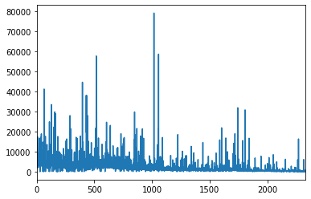

```python
import matplotlib.pyplot as plt
%matplotlib inline
add_data_clean.retweet_count.plot()

plt.show()
```

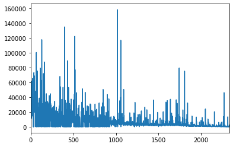

```python
add_data_clean.favorite_count.plot()

plt.show()
```

```python
twiter_cleaned.to_csv('twitter_archive_master.csv', index=False)
```

```python
add_data_clean.to_csv('twitterapi.csv', index=False)
```

```python
image_predictions_clean.to_csv('image.csv', index=False)
```